# Chapter 13

Julin N Maloof

1/8/2020

# Problems

## 12E1

*12E1. Which of the following priors will produce more shrinkage in the estimates? (a) αtank ∼ Normal(0, 1); (b) αtank ∼ Normal(0, 2).*

αtank ∼ Normal(0, 1)

## 12E2

*Make the following model into a multilevel model.*

Old: yi ∼ Binomial(1, pi)  
logit(pi) = αgroup[i] + βxi  
αgroup ∼ Normal(0, 1.5)  
β ∼ Normal(0, 1)

New: yi ∼ Binomial(1, pi)  
logit(pi) = αgroup[i] + βxi  
αgroup ∼ Normal(a_bar, sigma)  
a_bar ~ Normal(0, 1.5)  
sigma ~ dexp(0,1)  
β ∼ Normal(0, 1)

## 12E3

*Make the following model into a multilevel model.*

yi ∼ Normal(μi, σ)  
μi = αgroup[i] + βxi  
αgroup ∼ Normal(a_bar, sigma)  
a_bar ~ Normal(0, 10)  
sigma ~ dexp(1)  
β ∼ Normal(0, 1)  
σ ∼ HalfCauchy(0, 2)

## 12M1

*Revisit the Reed frog survival data, data(reedfrogs), and add the predation and size treatment variables to the varying intercepts model. Consider models with either main effect alone, both main effects, as well as a model including both and their interaction. Instead of focusing on inferences about these two predictor variables, focus on the inferred variation across tanks. Explain why it changes as it does across models.*

```r
library(rethinking)
library(tidyverse)
data(reedfrogs)
d <- reedfrogs
str(d)
```

```
## 'data.frame':    48 obs. of  5 variables:
##  $ density : int  10 10 10 10 10 10 10 10 10 10 ...
##  $ pred    : Factor w/ 2 levels "no","pred": 1 1 1 1 1 1 1 1 2 2 ...
##  $ size    : Factor w/ 2 levels "big","small": 1 1 1 1 2 2 2 2 1 1 ...
##  $ surv    : int  9 10 7 10 9 9 10 9 4 9 ...
##  $ propsurv: num  0.9 1 0.7 1 0.9 0.9 1 0.9 0.4 0.9 ...
```

```r
# make the tank cluster variable
d$tank <- 1:nrow(d)
```

orignal

```r
dat <- list(
  S = d$surv,
  N = d$density,
  tank = d$tank
)

m12M1a <- ulam(
  alist(
    S ~ dbinom( N , p ) ,
    logit(p) <- a[tank] ,
    a[tank] ~ dnorm( a_bar , sigma ) ,
    a_bar ~ dnorm( 0 , 1.5 ) ,
    sigma ~ dexp( 1 )
  ), data=dat , chains=4 , log_lik=TRUE )
dat <- list(
  S = d$surv,
  N = d$density,
  tank = d$tank,
  pred = ifelse(d$pred=="no", 0, 1)
)

m12M1_pred <- ulam(
  alist(
    S ~ dbinom( N , p ) ,
    logit(p) <- a[tank] + b_pred*pred,
    a[tank] ~ dnorm( a_bar , sigma ) ,
    a_bar ~ dnorm( 0 , 1.5 ) ,
    b_pred ~ dnorm(0, 1),
    sigma ~ dexp( 1 )
  ), data=dat , chains=4 , log_lik=TRUE, iter = 2000 )
precis(m12M1_pred, depth = 2)
```

```
##              mean        sd        5.5%     94.5%     n_eff      Rhat
## a[1]    2.4591324 0.6868003  1.38741002  3.576655 3622.2866 0.9992610
## a[2]    2.9494307 0.7483510  1.84312318  4.202269 3063.7934 1.0017836
## a[3]    1.6863535 0.6203339  0.72453809  2.677431 2955.8394 1.0014602
## a[4]    2.9465731 0.7321893  1.79987125  4.122627 3289.5782 0.9992734
## a[5]    2.4655851 0.6967320  1.41055014  3.610224 4189.3361 0.9992898
## a[6]    2.4658830 0.6615723  1.42125186  3.524196 4075.4602 0.9993694
## a[7]    2.9359483 0.7404571  1.80747492  4.147557 2887.1451 0.9998130
## a[8]    2.4620877 0.6884033  1.37437873  3.595281 3832.4972 0.9999999
## a[9]    2.1965103 0.5768223  1.28040910  3.117884 1467.3008 1.0026351
## a[10]   3.5347146 0.6018344  2.60108525  4.535452 1790.8737 1.0003596
## a[11]   2.9719244 0.5689543  2.08171252  3.912435 1608.9204 1.0017561
## a[12]   2.7051067 0.5916773  1.79542011  3.664656 1392.1574 1.0005578
## a[13]   2.9550816 0.5798877  2.03265190  3.894736 1375.9258 1.0029552
## a[14]   2.4577953 0.5806957  1.53832800  3.384974 1434.8751 1.0021336
## a[15]   3.5508055 0.6192356  2.60586451  4.587951 1803.1425 0.9996693
## a[16]   3.5392516 0.6270197  2.58450297  4.567303 1737.9744 1.0008881
## a[17]   2.8810305 0.6094448  1.94813438  3.912312 2843.4286 0.9999668
## a[18]   2.5563395 0.5737219  1.68961876  3.501414 4055.6643 0.9995368
## a[19]   2.2670180 0.5369011  1.45045354  3.164633 3485.1749 0.9997313
## a[20]   3.2727395 0.6800229  2.26443467  4.417523 2635.9716 1.0012268
## a[21]   2.5474459 0.5698501  1.67668469  3.499468 3722.5079 0.9992950
## a[22]   2.5439363 0.5551793  1.69414610  3.444997 3544.6260 0.9994211
## a[23]   2.5402282 0.5724098  1.67124746  3.509777 3334.6663 0.9994759
## a[24]   2.0083244 0.4888913  1.26315622  2.797572 3738.9629 1.0008717
## a[25]   1.5283352 0.4825059  0.73541101  2.267604  992.7390 1.0037776
## a[26]   2.4985114 0.4558177  1.75611743  3.226188  983.2127 1.0031439
## a[27]   1.2117820 0.5112013  0.37792490  2.002536 1031.3639 1.0043015
## a[28]   1.9579766 0.4702821  1.18080428  2.700862  861.5955 1.0038656
## a[29]   2.4942732 0.4614963  1.75346911  3.210305  923.8483 1.0022945
## a[30]   3.4785076 0.4797506  2.73735684  4.252663 1188.0412 1.0010264
## a[31]   1.8221978 0.4697021  1.05702940  2.563950  791.3581 1.0050674
## a[32]   2.0907656 0.4637651  1.34047067  2.824913  869.5126 1.0030371
## a[33]   3.0599886 0.6107951  2.14137312  4.099614 2940.9563 1.0001637
## a[34]   2.7456364 0.5412002  1.91792325  3.655987 2809.9326 1.0015949
## a[35]   2.7610547 0.5458551  1.94262503  3.665487 3986.8678 1.0000664
## a[36]   2.2388511 0.4731947  1.51892148  3.002726 4966.4540 0.9996432
## a[37]   2.2571419 0.4773090  1.52770899  3.053663 4233.3501 1.0002702
## a[38]   3.4158950 0.6689528  2.41947321  4.563227 3189.9174 1.0006281
## a[39]   2.7411771 0.5362413  1.92311562  3.626552 3472.5917 0.9997377
## a[40]   2.4859722 0.4927202  1.72936084  3.300129 4015.6382 0.9996036
## a[41]   0.8805223 0.5013497  0.06024822  1.655143  900.5891 1.0043697
## a[42]   1.8680838 0.4345543  1.14546629  2.538888  759.7428 1.0050789
## a[43]   1.9664479 0.4353198  1.27140552  2.651228  767.8805 1.0036089
## a[44]   2.0738607 0.4173221  1.40489696  2.728853  768.9314 1.0032475
## a[45]   2.8677682 0.4268975  2.18923005  3.548865  759.4899 1.0039638
## a[46]   1.8630744 0.4366635  1.16269704  2.549777  777.9587 1.0049758
## a[47]   3.9750265 0.4941841  3.22081700  4.807156 1317.2750 1.0004346
## a[48]   2.3724356 0.4201336  1.70831678  3.030300  767.7870 1.0049313
## a_bar   2.5186881 0.2309149  2.15402072  2.889354  622.9332 1.0034115
## b_pred -2.4021236 0.2995116 -2.86821142 -1.909262  398.7277 1.0080903
## sigma   0.8255247 0.1436727  0.61350444  1.073442 1158.4691 1.0070359
```

```
## 48 vector or matrix parameters hidden. Use depth=2 to show them.
```

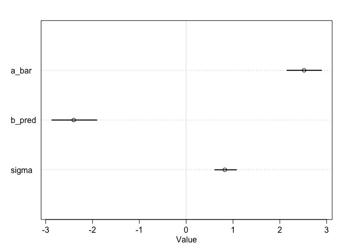

```r
plot(m12M1_pred)
```

size model

```r
dat <- list(
  S = d$surv,
  N = d$density,
  tank = d$tank,
  sze = ifelse(d$size=="small", 0, 1)
)

str(dat)
```

```
## List of 4
##  $ S   : int [1:48] 9 10 7 10 9 9 10 9 4 9 ...
##  $ N   : int [1:48] 10 10 10 10 10 10 10 10 10 10 ...
##  $ tank: int [1:48] 1 2 3 4 5 6 7 8 9 10 ...
##  $ sze : num [1:48] 1 1 1 1 0 0 0 0 1 1 ...
```

```r
m12M1_size <- ulam(
  alist(
    S ~ dbinom( N , p ) ,
    logit(p) <- a[tank] + b_size*sze,
    a[tank] ~ dnorm( a_bar , sigma ) ,
    a_bar ~ dnorm( 0 , 1.5 ) ,
    b_size ~ dnorm(0, 1),
    sigma ~ dexp( 1 )
  ), data=dat , chains=4 , iter=4000, log_lik=TRUE )
precis(m12M1_size)
```

```
## 48 vector or matrix parameters hidden. Use depth=2 to show them.
```

```
##              mean        sd       5.5%     94.5%     n_eff     Rhat
## a_bar   1.4880629 0.3375462  0.9426560 2.0286841 1564.2553 1.000467
## b_size -0.2842944 0.4646782 -0.9977492 0.4708924  983.8116 1.001538
## sigma   1.6218643 0.2158522  1.3100961 1.9933574 4108.5082 1.000617
```

both size and pred

```r
dat <- list(
  S = d$surv,
  N = d$density,
  tank = d$tank,
  sze = ifelse(d$size=="small", 0, 1),
  pred = ifelse(d$pred=="no", 0, 1)
)

m12M1_both <- ulam(
  alist(
    S ~ dbinom( N , p ) ,
    logit(p) <- a[tank] + b_pred*pred + b_size*sze,
    a[tank] ~ dnorm( a_bar , sigma ) ,
    a_bar ~ dnorm( 0 , 1.5 ) ,
    b_pred ~ dnorm(0, 1),
    b_size ~ dnorm(0, 1),
    sigma ~ dexp( 1 )
  ), data=dat , chains=4 , log_lik=TRUE, iter=4000 )
precis(m12M1_both)
```

```
## 48 vector or matrix parameters hidden. Use depth=2 to show them.
```

```
##             mean        sd       5.5%       94.5%    n_eff     Rhat
## a_bar   2.704880 0.2616757  2.2849557  3.12134670 1053.147 1.001860
## b_pred -2.387739 0.2888676 -2.8474543 -1.91922079 1429.418 1.000812
## b_size -0.418927 0.2851242 -0.8712235  0.04358124 1802.190 1.001189
## sigma   0.782561 0.1468009  0.5660256  1.03211955 2054.049 1.000549
```

interaction

```r
dat <- list(
  S = d$surv,
  N = d$density,
  tank = d$tank,
  sze = ifelse(d$size=="small", 0, 1),
  pred = ifelse(d$pred=="no", 0, 1)
)

m12M1_int <- ulam(
  alist(
    S ~ dbinom( N , p ) ,
    logit(p) <- a[tank] + b_pred*pred + b_size*sze +b_int*pred*sze,
    a[tank] ~ dnorm( a_bar , sigma ) ,
    a_bar ~ dnorm( 0 , 1.5 ) ,
    b_pred ~ dnorm(0, 1),
    b_size ~ dnorm(0, 1),
    b_int ~ dnorm(0, .5),
    sigma ~ dexp( 1 )
  ), data=dat , chains=4 , log_lik=TRUE, iter=4000 )
precis(m12M1_int)
```

```
## 48 vector or matrix parameters hidden. Use depth=2 to show them.
```

```
##              mean        sd       5.5%       94.5%    n_eff     Rhat
## a_bar   2.5474694 0.2701091  2.1189142  2.98331805 1238.620 1.002829
## b_pred -2.1043752 0.3160943 -2.6109789 -1.60339299 1623.244 1.001706
## b_size -0.0599948 0.3403588 -0.6069567  0.48917465 1855.220 1.001143
## b_int  -0.6600615 0.3621325 -1.2405429 -0.08222024 3455.152 1.000018
## sigma   0.7372838 0.1452065  0.5182001  0.98265245 2219.577 1.000141
```

```r
coeftab(m12M1a, m12M1_pred, m12M1_size, m12M1_both, m12M1_int)@coefs %>%
  as.data.frame() %>%
  rownames_to_column(var="coef") %>%
  filter(str_detect(coef, "\\[", negate = TRUE))
```

```
##     coef m12M1a m12M1_pred m12M1_size m12M1_both m12M1_int
## 1  a_bar   1.35       2.52       1.49       2.70      2.55
## 2  sigma   1.62       0.83       1.62       0.78      0.74
## 3 b_pred     NA      -2.40         NA      -2.39     -2.10
## 4 b_size     NA         NA      -0.28      -0.42     -0.06
## 5  b_int     NA         NA         NA         NA     -0.66
```

## 12M2

*Compare the models you fit just above, using WAIC. Can you reconcile the differences in WAIC with the posterior distributions of the models?*

```r
compare(m12M1a, m12M1_pred, m12M1_size, m12M1_both, m12M1_int)
```

```
##                WAIC       SE     dWAIC      dSE    pWAIC    weight
## m12M1_pred 198.8558 8.958127 0.0000000       NA 19.08226 0.3412016
## m12M1_int  199.6347 9.116453 0.7788881 2.767821 18.92918 0.2311414
## m12M1_both 200.2888 8.636651 1.4330196 1.883515 19.29798 0.1666613
## m12M1_size 200.7285 7.169761 1.8727077 5.670432 21.16502 0.1337697
## m12M1a     200.8288 7.358062 1.9730166 5.552666 21.19541 0.1272260
```

I would have thought that the pred or both models would have been notably better than the intercept only model.

## 12M3

Re-estimate the basic Reed frog varying intercept model, but now using a Cauchy distribution in place of the Gaussian distribution for the varying intercepts.

Compare the posterior means of the intercepts, αtank, to the posterior means produced in the chapter, using the customary Gaussian prior. Can you explain the pattern of differences?

```r
dat <- list(
  S = d$surv,
  N = d$density,
  tank = d$tank
)

m12M3 <- ulam(
  alist(
    S ~ dbinom( N , p ) ,
    logit(p) <- a[tank] ,
    a[tank] ~ dcauchy( a_bar , sigma ) ,
    a_bar ~ dnorm( 0 , 1.5 ) ,
    sigma ~ dcauchy(0, 1)
  ), data=dat , chains=4 , log_lik=TRUE )
```

now compare the models.

```r
precis(m12M1a)
```

```
## 48 vector or matrix parameters hidden. Use depth=2 to show them.
```

```
##           mean        sd      5.5%    94.5%    n_eff      Rhat
## a_bar 1.348012 0.2569801 0.9482239 1.766252 2433.513 0.9991427
## sigma 1.620087 0.2187757 1.3028842 2.001006 1276.164 0.9997024
```

```r
precis(m12M3)
```

```
## 48 vector or matrix parameters hidden. Use depth=2 to show them.
```

```
##           mean        sd      5.5%    94.5%    n_eff      Rhat
## a_bar 1.480218 0.2998824 0.9974749 1.942537 1186.705 1.0001667
## sigma 1.013529 0.2195519 0.6853115 1.372769 1520.281 0.9989392
```

```r
compare(m12M1a, m12M3)
```

```
##            WAIC       SE    dWAIC      dSE    pWAIC    weight
## m12M1a 200.8288 7.358062 0.000000       NA 21.19541 0.8351683
## m12M3  204.0742 8.313576 3.245417 2.387018 23.45348 0.1648317
```

```r
pred.orig <- link(m12M1a)

pred.cauchy <- link(m12M3)

results <-rbind(
  data.frame(
    tank=1:48,
    mu=apply(pred.orig, 2, mean),
    hdpi.low=apply(pred.orig, 2, HPDI)[1,],
    hdpi.high=apply(pred.orig, 2, HPDI)[2,],
    model="Gaussian"),
  data.frame(
    tank=1:48,
    mu=apply(pred.cauchy, 2, mean),
    hdpi.low=apply(pred.cauchy, 2, HPDI)[1,],
    hdpi.high=apply(pred.cauchy, 2, HPDI)[2,],
    model="Cauchy")
)
```

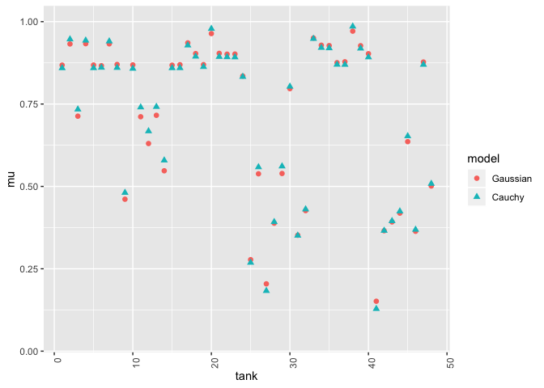

```r
results %>%
  ggplot(aes(x=tank, y=mu, ymin=hdpi.low, ymax=hdpi.high, color=model, shape=model)) +
  geom_point(size=2) +
  theme(axis.text.x = element_text(angle=90, hjust=1))
```

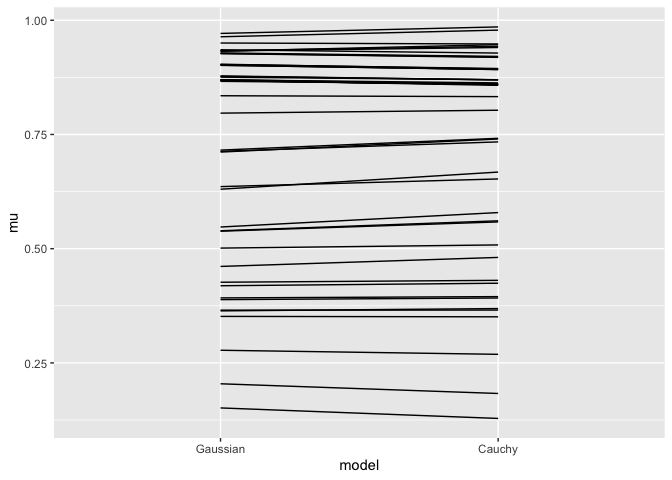

```r
results %>%
  ggplot(aes(x=model, y=mu, group=tank)) +
  geom_line()
```

Cuachy distribution has fatter tails so we see a bit of a spread in the tank estimates….

## 12M4

OKay this was in the book…

```r
## R code 13.21
library(rethinking)
data(chimpanzees)
d <- chimpanzees
d$treatment <- 1 + d$prosoc_left + 2*d$condition

dat_list <- list(
  pulled_left = d$pulled_left,
  actor = d$actor,
  block_id = d$block,
  treatment = as.integer(d$treatment) )

set.seed(13)
m13.4 <- ulam(
  alist(
    pulled_left ~ dbinom( 1 , p ) ,
    logit(p) <- a[actor] + g[block_id] + b[treatment] ,
    b[treatment] ~ dnorm( 0 , 0.5 ),
    # adaptive priors
    a[actor] ~ dnorm( a_bar , sigma_a ),
    g[block_id] ~ dnorm( 0 , sigma_g ),
    # hyper-priors
    a_bar ~ dnorm( 0 , 1.5 ),
    sigma_a ~ dexp(1),
    sigma_g ~ dexp(1)
  ) , data=dat_list , chains=4 , cores=4 , log_lik=TRUE )
## R code 13.22
precis( m13.4 , depth=2 )
```

```
##                mean        sd        5.5%        94.5%     n_eff     Rhat
## b[1]    -0.11690849 0.3011362 -0.59089823  0.388027611  158.0734 1.030259
## b[2]     0.40367920 0.2993664 -0.07243773  0.876281406  310.1579 1.017015
## b[3]    -0.47517242 0.2982659 -0.96121444 -0.001208767  514.5166 1.009468
## b[4]     0.30223326 0.3062024 -0.16969249  0.797988770  186.4974 1.021001
## a[1]    -0.36616417 0.3585130 -0.94055086  0.242096169  445.8348 1.011758
## a[2]     4.60765170 1.2025595  2.97569348  6.831933378  915.4325 1.008771
## a[3]    -0.67157756 0.3646073 -1.24345640 -0.078383728  708.5391 1.007395
## a[4]    -0.67815263 0.3654014 -1.26252548 -0.093317530  234.9853 1.019278
## a[5]    -0.37347321 0.3576212 -0.93033429  0.191634975  337.7865 1.013853
## a[6]     0.56781505 0.3450970  0.01493180  1.119769346  559.8562 1.009294
## a[7]     2.09058800 0.4477239  1.40803121  2.821500334  721.4185 1.010104
## g[1]    -0.16773309 0.2214237 -0.56899632  0.067615618  426.3964 1.007305
## g[2]     0.04666713 0.1766454 -0.18776887  0.355726581  921.3437 1.007404
## g[3]     0.05447137 0.1889605 -0.22254139  0.393896427 1062.2701 1.007080
## g[4]     0.01627582 0.1758810 -0.24521607  0.311856360  938.6204 1.008535
## g[5]    -0.02273205 0.1805091 -0.31235331  0.243453720  872.8554 1.002842
## g[6]     0.11643591 0.1931547 -0.10661896  0.486435415  533.3200 1.010657
## a_bar    0.57583733 0.7440793 -0.57786389  1.791021290  800.3107 1.000534
## sigma_a  1.99734206 0.6599766  1.17313475  3.158635609 1106.0906 1.004157
## sigma_g  0.21326993 0.1725644  0.02710867  0.520068155  228.7446 1.016867
```

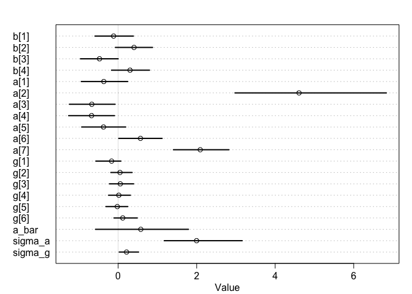

```r
plot( precis(m13.4,depth=2) ) # also plot
```

## 12H1

```r
data("bangladesh")
d <- bangladesh
d$district_id <- as.integer(as.factor(d$district))
str(d)
```

```
## 'data.frame':    1934 obs. of  7 variables:
##  $ woman            : int  1 2 3 4 5 6 7 8 9 10 ...
##  $ district         : int  1 1 1 1 1 1 1 1 1 1 ...
##  $ use.contraception: int  0 0 0 0 0 0 0 0 0 0 ...
##  $ living.children  : int  4 1 3 4 1 1 4 4 2 4 ...
##  $ age.centered     : num  18.44 -5.56 1.44 8.44 -13.56 ...
##  $ urban            : int  1 1 1 1 1 1 1 1 1 1 ...
##  $ district_id      : int  1 1 1 1 1 1 1 1 1 1 ...
```

fixed effect model

```r
dat = list(district_id=d$district_id, contraception=d$use.contraception)
str(dat)
```

```
## List of 2
##  $ district_id  : int [1:1934] 1 1 1 1 1 1 1 1 1 1 ...
##  $ contraception: int [1:1934] 0 0 0 0 0 0 0 0 0 0 ...
```

```r
M12H1a <- ulam(
  alist(contraception ~ dbinom(1, p),
        logit(p) <- a[district_id],
        a[district_id] ~ dnorm(0, 1.5)),
  data = dat, chains = 4, log_lik = TRUE)
precis(M12H1a, depth=2) %>% head()
```

```
##              mean        sd       5.5%      94.5%    n_eff      Rhat
## a[1] -1.055508523 0.2097928 -1.3937164 -0.7259341 5985.211 0.9983548
## a[2] -0.577780977 0.4564626 -1.3375017  0.1562800 4973.877 0.9995361
## a[3]  1.252437033 1.1429624 -0.4936847  3.1576095 4002.102 0.9997920
## a[4]  0.001140096 0.3649918 -0.5760228  0.5774228 5528.479 0.9986286
## a[5] -0.561290968 0.3302895 -1.0971290 -0.0395408 4869.066 0.9992659
## a[6] -0.869425539 0.2615467 -1.3046892 -0.4550778 5088.273 0.9987757
```

multi-level model:

```r
M12H1b <- ulam(
  alist(contraception ~ dbinom(1, p),
        logit(p) <- a[district_id],
        a[district_id] ~ dnorm(a_bar, sigma),
        a_bar ~ dnorm(0, 1.5),
        sigma ~ dexp(1)),
  data = dat, chains = 4, log_lik = TRUE, cores=4 )
```

```r
precis(M12H1b, depth=2) %>% head()
```

```
##            mean        sd       5.5%       94.5%    n_eff      Rhat
## a[1] -0.9899552 0.1949003 -1.3064550 -0.68959192 3538.005 0.9989767
## a[2] -0.5833494 0.3614593 -1.1662371 -0.02014006 3181.558 0.9993799
## a[3] -0.2317480 0.5063911 -1.0012614  0.56429226 3322.489 0.9988790
## a[4] -0.1862491 0.3076827 -0.6733492  0.31259755 4265.280 0.9982174
## a[5] -0.5769672 0.2769154 -1.0352410 -0.15479266 4081.103 0.9999938
## a[6] -0.8132207 0.2349686 -1.1890557 -0.44547849 3712.211 0.9988048
```

```r
compare(M12H1a, M12H1b)
```

```
##            WAIC       SE    dWAIC      dSE    pWAIC    weight
## M12H1b 2514.625 25.02452 0.000000       NA 35.68721 0.9899578
## M12H1a 2523.806 28.91864 9.181733 7.744964 53.86767 0.0100422
```

Hierarchical model strongly preferred

#### make the plots…

First, get posterior samples

```r
pred.df <- data.frame(district_id=unique(dat$district_id))
pred1 <- link(M12H1a, pred.df)
dim(pred1)
```

```
## [1] 2000   60
```

```r
pred1[1:5, 1:5]
```

```
##           [,1]      [,2]      [,3]      [,4]      [,5]
## [1,] 0.2682002 0.2921103 0.3718680 0.4466180 0.5102328
## [2,] 0.2824183 0.2677161 0.8232001 0.4607534 0.4462490
## [3,] 0.2383377 0.3916201 0.5339876 0.4641540 0.2901981
## [4,] 0.2956614 0.1764319 0.8477259 0.5849533 0.3637553
## [5,] 0.3291904 0.2917012 0.8712058 0.4941575 0.3785319
```

```r
range(pred1) #already transformed
```

```
## [1] 0.001290472 0.994420739
```

```r
pred2 <- link(M12H1b, pred.df)
```

summarize samples

```r
results1 <- data.frame(
  district_id=1:60,
  mu=apply(pred1, 2, mean),
  hdpi.low=apply(pred1, 2, HPDI)[1,],
  hdpi.high=apply(pred1, 2, HPDI)[2,],
  model="fixed")

results2 <- data.frame(
  district_id=1:60,
  mu=apply(pred2, 2, mean),
  hdpi.low=apply(pred2, 2, HPDI)[1,],
  hdpi.high=apply(pred2, 2, HPDI)[2,],
  model="hierarchical")

resultsall <- rbind(results1, results2)
head(resultsall)
```

```
##   district_id        mu  hdpi.low hdpi.high model
## 1           1 0.2601827 0.1929196 0.3192789 fixed
## 2           2 0.3657578 0.1844353 0.5121860 fixed
## 3           3 0.7297899 0.4611118 0.9807792 fixed
## 4           4 0.5002387 0.3688746 0.6454500 fixed
## 5           5 0.3665914 0.2456246 0.4844333 fixed
## 6           6 0.2982258 0.2062912 0.3766310 fixed
```

add sample size per district so that I can use this in plotting:

```r
resultsall <- d %>%
  group_by(district_id) %>%
  summarize(size=n()) %>%
  right_join(resultsall)
```

I want to order the plotting by the differnce between the models

```r
resultsdiff <-
  resultsall %>%
  select(district_id, size, model, mu) %>%
  spread(key = model, value = mu) %>%
  mutate(diff=abs(fixed-hierarchical))

plotorder <- resultsdiff  %>%
  arrange(diff) %>%
  pull(district_id) %>%
  as.character()
```

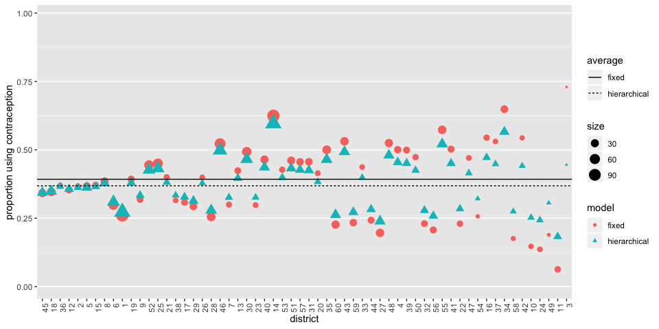

```r
hlines <- data.frame(
  average=c("fixed", "hierarchical"),
  estimate=c(mean(d$use.contraception),
             inv_logit(coef(M12H1b)["a_bar"])
  ))

resultsall %>%
  ggplot(aes(x=as.factor(district_id), y=mu, ymin=hdpi.low, ymax=hdpi.high, fill=model, color=model, shape=model, size=size)) +
  geom_point() +
  scale_x_discrete(limits=plotorder) +
  geom_hline(aes(yintercept = estimate, linetype = average), data=hlines) +
  theme(axis.text.x = element_text(angle=90, hjust=1),panel.grid.major.x = element_blank()) +
  ylab("proportion using contraception") +
  xlab("district")
```

Two determinants: sample size and distance from overall mean

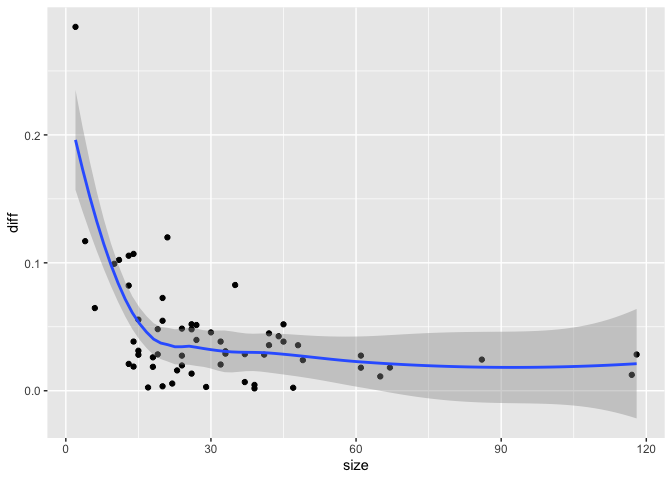

```r
resultsdiff %>%
  ggplot(aes(x=size,y=diff)) +
  geom_point() +
  geom_smooth()
```

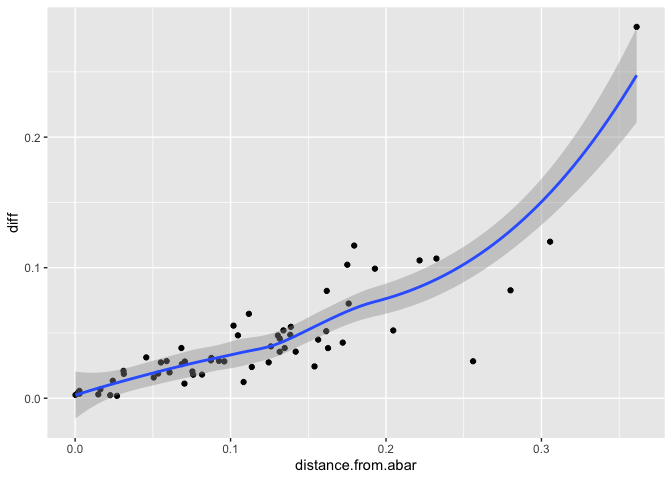

```r
resultsdiff %>%
  mutate(distance.from.abar=abs(fixed-inv_logit(coef(M12H1b)["a_bar"]))) %>%
  ggplot(aes(x=distance.from.abar,y=diff)) +
  geom_point() +
  geom_smooth()
```

## 12H2

*Return to the Trolley data, data(Trolley), from Chapter 12. Define and fit a varying intercepts model for these data. Cluster intercepts on individual participants, as indicated by the unique values in the id variable. Include action, intention, and contact as ordinary terms. Compare the varying intercepts model and a model that ignores individuals, using both WAIC and posterior predictions. What is the impact of individual variation in these data?*

```r
data(Trolley)

d <- Trolley

dat <- list(
  R = d$response,
  A = d$action,
  I = d$intention,
  C = d$contact,
  id = d$id)

system.time({
  m12H2a <- ulam(
    alist(
      R ~ dordlogit( phi , cutpoints ),
      phi <- bA*A + bC*C + BI*I ,
      BI <- bI + bIA*A + bIC*C ,
      c(bA,bI,bC,bIA,bIC) ~ dnorm( 0 , 0.5 ),
      cutpoints ~ dnorm( 0 , 1.5 )
    ) , data=dat , chains=4 , cores=4, log_lik = TRUE )
})
```

```
##     user   system  elapsed
## 3095.605   14.151  955.351
```

```r
system.time({
  m12H2b <- ulam( alist(
  R ~ dordlogit( phi , cutpoints ),
  phi <- alpha[id] + bA*A + bC*C + BI*I ,
  BI <- bI + bIA*A + bIC*C ,
  alpha[id] ~ dnorm(0, sigma),
  c(bA,bI,bC,bIA,bIC) ~ dnorm( 0 , 0.5 ),
  cutpoints ~ dnorm( 0 , 1.5 ),
  sigma ~ dexp(1)) ,
  data=dat,
  chains=4,
  cores=4,
  log_lik = TRUE)
})
```

```
##     user   system  elapsed
## 6625.282   22.618 1961.295
```

```r
precis(m12H2a)
```

```
## 6 vector or matrix parameters hidden. Use depth=2 to show them.
```

```
##           mean         sd       5.5%      94.5%    n_eff     Rhat
## bIC -1.2345616 0.09357473 -1.3796292 -1.0860197 1391.413 1.002759
## bIA -0.4332886 0.07908662 -0.5569181 -0.2988533 1245.676 1.001838
## bC  -0.3429776 0.06600206 -0.4501328 -0.2375302 1207.872 1.003097
## bI  -0.2918034 0.05490015 -0.3790827 -0.2062375 1143.792 1.004232
## bA  -0.4726172 0.05222480 -0.5559474 -0.3934316 1082.908 1.004165
```

```r
precis(m12H2b)
```

```
## 337 vector or matrix parameters hidden. Use depth=2 to show them.
```

```
##             mean         sd       5.5%      94.5%     n_eff     Rhat
## bIC   -1.6785190 0.10285814 -1.8473615 -1.5198136  939.4153 1.005209
## bIA   -0.5675747 0.08081362 -0.6991112 -0.4353545 1188.1897 1.000504
## bC    -0.4458475 0.07254937 -0.5598957 -0.3274683  990.7274 1.005766
## bI    -0.3790743 0.06031320 -0.4755543 -0.2810565  947.5081 1.002956
## bA    -0.6432736 0.05648863 -0.7356979 -0.5526233 1057.6945 1.002423
## sigma  1.9169551 0.08202872  1.7906309  2.0505250 2075.1195 1.001075
```

```r
compare(m12H2a, m12H2b)
```

```
##            WAIC        SE    dWAIC      dSE     pWAIC weight
## m12H2b 31057.26 179.43726    0.000       NA 356.54433      1
## m12H2a 36928.40  80.68143 5871.143 173.5793  10.54528      0
```

[figure not shown]

```r
plot(coeftab(m12H2a, m12H2b))
```

## 12H3

```r
data(Trolley)

d <- Trolley

dat <- list(
  R = d$response,
  A = d$action,
  I = d$intention,
  C = d$contact,
  id = d$id,
  st = d$story)

system.time({
  m12H3 <- ulam( alist(
  R ~ dordlogit( phi , cutpoints ),
  phi <- alpha[id] + gamma[st] + bA*A + bC*C + BI*I ,
  BI <- bI + bIA*A + bIC*C ,
  alpha[id] ~ dnorm(0, sigma_alpha),
  gamma[st] ~ dnorm(0, sigma_gamma),
  c(bA,bI,bC,bIA,bIC) ~ dnorm( 0 , 0.5 ),
  cutpoints ~ dnorm( 0 , 1.5 ),
  sigma_alpha ~ dexp(1),
  sigma_gamma ~ dexp(1)) ,
  data=dat,
  chains=4,
  cores=4,
  log_lik = TRUE)
})
```

```
##      user    system   elapsed
## 10487.754    91.589  3892.325
```

```r
precis(m12H3,depth=2)
```

```
##                      mean         sd         5.5%       94.5%     n_eff
## alpha[1]     -0.540299835 0.31699890 -1.056281018 -0.04171369  633.0168
## alpha[2]     -1.685456195 0.43555351 -2.357715107 -0.99562714 1078.8877
## alpha[3]     -2.999032111 0.41078831 -3.692912250 -2.35568768  830.7199
## alpha[4]     -0.351198761 0.48417124 -1.094083909  0.45538292 1280.9385
## alpha[5]     -3.513446170 0.42035578 -4.199376227 -2.83304391  885.8911
## alpha[6]      0.704989555 0.34054077  0.152594659  1.22858753  527.1775
## alpha[7]     -0.374953777 0.32366867 -0.901917938  0.15058790  450.1903
## alpha[8]      3.976327201 0.48973716  3.215210410  4.79488775 1523.7898
## alpha[9]     -0.860599621 0.32121249 -1.381848512 -0.35041530  646.4865
## alpha[10]     0.807606215 0.33540377  0.275065587  1.34875756  895.7052
## alpha[11]     0.593401637 0.34694516  0.032714046  1.14267168  853.0819
## alpha[12]     2.449248029 0.39232513  1.816253492  3.06382407  927.7531
## alpha[13]    -0.422015948 0.30845321 -0.921012040  0.04088898  726.4361
## alpha[14]    -0.965856330 0.34035515 -1.512177272 -0.42023361  726.6480
## alpha[15]     1.742302442 0.33674122  1.190060977  2.27293219  676.4000
## alpha[16]    -1.867074540 0.44084887 -2.587914763 -1.15464264 1212.1965
## alpha[17]     1.692223682 0.47738663  0.948613118  2.45970762 1381.4228
## alpha[18]    -1.152775922 0.36081578 -1.708032194 -0.55272839  837.3678
## alpha[19]    -1.359350139 0.32065327 -1.873668077 -0.83516829  730.5733
## alpha[20]    -0.524408057 0.31365096 -1.010511536 -0.02551755  638.7476
## alpha[21]    -2.168173812 0.34328427 -2.725022747 -1.62415194  878.1258
## alpha[22]     0.033169167 0.36690646 -0.555417276  0.63046978  796.0070
## alpha[23]    -5.356205500 0.58555086 -6.337644406 -4.48802266 1319.5666
## alpha[24]    -1.738725583 0.31438268 -2.243658870 -1.22347493  657.9829
## alpha[25]    -0.661949908 0.32901617 -1.206716650 -0.14513543  582.5219
## alpha[26]     0.936546914 0.32150024  0.410479490  1.43908123  592.0607
## alpha[27]     1.124140056 0.45646001  0.400418009  1.86029649 1628.8009
## alpha[28]    -0.806649666 0.34523484 -1.360869373 -0.26300273  729.5453
## alpha[29]     1.249064044 0.33018983  0.720580420  1.78132566  427.5327
## alpha[30]     1.752283619 0.33517651  1.216651652  2.28458786  642.1522
## alpha[31]     3.931219389 0.42986810  3.271551464  4.66475340 1056.7595
## alpha[32]    -0.683866836 0.31961617 -1.198754402 -0.15333814  676.6326
## alpha[33]    -0.181053949 0.30999172 -0.681906598  0.30939054  516.2098
## alpha[34]    -1.959108589 0.34498739 -2.506952493 -1.40346884  559.6148
## alpha[35]     1.444259057 0.33173003  0.895322257  1.97263597  655.7560
## alpha[36]     1.680050779 0.30160324  1.204405453  2.17198969  641.4000
## alpha[37]     1.143890426 0.42949383  0.438373790  1.81128787  914.4859
## alpha[38]     0.712678919 0.31529868  0.222172862  1.22486972  842.7520
## alpha[39]     1.257710776 0.34231741  0.697840598  1.79085248  727.0920
```

[output cut: 659 more lines]

```
## gamma[11]    1.0130271
## gamma[12]    1.0171347
## bIC          1.0004851
## bIA          1.0020745
## bC           1.0009155
## bI           1.0024427
## bA           1.0029040
## cutpoints[1] 1.0307984
## cutpoints[2] 1.0312306
## cutpoints[3] 1.0323353
## cutpoints[4] 1.0337475
## cutpoints[5] 1.0348237
## cutpoints[6] 1.0361810
## sigma_alpha  0.9997672
## sigma_gamma  1.0029193
```

```r
compare(M12H1a, M12H1b, m12H3)
```

```
##             WAIC        SE        dWAIC       dSE     pWAIC    weight
## M12H1b  2514.625  25.02452     0.000000        NA  35.68721 0.9899578
## M12H1a  2523.806  28.91864     9.181733  7.744964  53.86767 0.0100422
## m12H3  30566.335 180.35142 28051.709905 83.420207 365.49599 0.0000000
```

# Book

```r
knitr::opts_chunk$set(eval = FALSE)
```

```r
## R code 13.1
library(rethinking)
data(reedfrogs)
d <- reedfrogs
str(d)

## R code 13.2
# make the tank cluster variable
d$tank <- 1:nrow(d)

dat <- list(
  S = d$surv,
  N = d$density,
  tank = d$tank )
```

```r
# approximate posterior
m13.1 <- ulam(
  alist(
    S ~ dbinom( N , p ) ,
    logit(p) <- a[tank] ,
    a[tank] ~ dnorm( 0 , 1.5 )
  ), data=dat , chains=4 , log_lik=TRUE )
```

```r
## R code 13.3
m13.2 <- ulam(
  alist(
    S ~ dbinom( N , p ) ,
    logit(p) <- a[tank] ,
    a[tank] ~ dnorm( a_bar , sigma ) ,
    a_bar ~ dnorm( 0 , 1.5 ) ,
    sigma ~ dexp( 1 )
  ), data=dat , chains=4 , log_lik=TRUE )
```

```r
## R code 13.4
compare( m13.1 , m13.2 )
```

```r
## R code 13.5
# extract Stan samples
post <- extract.samples(m13.2)

# compute median intercept for each tank
# also transform to probability with logistic
d$propsurv.est <- logistic( apply( post$a , 2 , mean ) )

# display raw proportions surviving in each tank
plot( d$propsurv , ylim=c(0,1) , pch=16 , xaxt="n" ,
      xlab="tank" , ylab="proportion survival" , col=rangi2 )
axis( 1 , at=c(1,16,32,48) , labels=c(1,16,32,48) )

# overlay posterior means
points( d$propsurv.est )

# mark posterior mean probability across tanks
abline( h=mean(inv_logit(post$a_bar)) , lty=2 )

# draw vertical dividers between tank densities
abline( v=16.5 , lwd=0.5 )
abline( v=32.5 , lwd=0.5 )
text( 8 , 0 , "small tanks" )
text( 16+8 , 0 , "medium tanks" )
text( 32+8 , 0 , "large tanks" )
```

```r
## R code 13.6
# show first 100 populations in the posterior
plot( NULL , xlim=c(-3,4) , ylim=c(0,0.35) ,
      xlab="log-odds survive" , ylab="Density" )
for ( i in 1:100 )
  curve( dnorm(x,post$a_bar[i],post$sigma[i]) , add=TRUE ,
         col=col.alpha("black",0.2) )

# sample 8000 imaginary tanks from the posterior distribution
sim_tanks <- rnorm( 8000 , post$a_bar , post$sigma )

# transform to probability and visualize
dens( inv_logit(sim_tanks) , lwd=2 , adj=0.1 )
```

```r
## R code 13.7
a_bar <- 1.5
sigma <- 1.5
nponds <- 60
Ni <- as.integer( rep( c(5,10,25,35) , each=15 ) )

## R code 13.8
set.seed(5005)
a_pond <- rnorm( nponds , mean=a_bar , sd=sigma )

## R code 13.9
dsim <- data.frame( pond=1:nponds , Ni=Ni , true_a=a_pond )
dsim
```

```r
## R code 13.10
class(1:3)
class(c(1,2,3))

## R code 13.11
dsim$Si <- rbinom( nponds , prob=logistic(dsim$true_a) , size=dsim$Ni )

## R code 13.12
dsim$p_nopool <- dsim$Si / dsim$Ni
dsim
```

```r
## R code 13.13
dat <- list( Si=dsim$Si , Ni=dsim$Ni , pond=dsim$pond )
m13.3 <- ulam(
  alist(
    Si ~ dbinom( Ni , p ),
    logit(p) <- a_pond[pond],
    a_pond[pond] ~ dnorm( a_bar , sigma ),
    a_bar ~ dnorm( 0 , 1.5 ),
    sigma ~ dexp( 1 )
  ), data=dat , chains=4 )
```

```r
## R code 13.14
precis( m13.3 , depth=2 )
```

```r
## R code 13.15
post <- extract.samples( m13.3 )
dsim$p_partpool <- apply( inv_logit(post$a_pond) , 2 , mean )

## R code 13.16
dsim$p_true <- inv_logit( dsim$true_a )

## R code 13.17
nopool_error <- abs( dsim$p_nopool - dsim$p_true )
partpool_error <- abs( dsim$p_partpool - dsim$p_true )

## R code 13.18
plot( 1:60 , nopool_error , xlab="pond" , ylab="absolute error" ,
      col=rangi2 , pch=16 )
points( 1:60 , partpool_error )

## R code 13.19
nopool_avg <- aggregate(nopool_error,list(dsim$Ni),mean)
partpool_avg <- aggregate(partpool_error,list(dsim$Ni),mean)
```

```r
## R code 13.20
a <- 1.5
sigma <- 1.5
nponds <- 60
Ni <- as.integer( rep( c(5,10,25,35) , each=15 ) )
a_pond <- rnorm( nponds , mean=a , sd=sigma )
dsim <- data.frame( pond=1:nponds , Ni=Ni , true_a=a_pond )
dsim$Si <- rbinom( nponds,prob=inv_logit( dsim$true_a ),size=dsim$Ni )
dsim$p_nopool <- dsim$Si / dsim$Ni
newdat <- list(Si=dsim$Si,Ni=dsim$Ni,pond=1:nponds)
m13.3new <- stan( fit=m13.3@stanfit , data=newdat , chains=4 )

post <- extract.samples( m13.3new )
dsim$p_partpool <- apply( inv_logit(post$a_pond) , 2 , mean )
dsim$p_true <- inv_logit( dsim$true_a )
nopool_error <- abs( dsim$p_nopool - dsim$p_true )
partpool_error <- abs( dsim$p_partpool - dsim$p_true )
plot( 1:60 , nopool_error , xlab="pond" , ylab="absolute error" , col=rangi2 , pch=16 )
points( 1:60 , partpool_error )

## R code 13.21
library(rethinking)
data(chimpanzees)
d <- chimpanzees
d$treatment <- 1 + d$prosoc_left + 2*d$condition

dat_list <- list(
  pulled_left = d$pulled_left,
  actor = d$actor,
  block_id = d$block,
  treatment = as.integer(d$treatment) )

set.seed(13)
m13.4 <- ulam(
  alist(
    pulled_left ~ dbinom( 1 , p ) ,
    logit(p) <- a[actor] + g[block_id] + b[treatment] ,
    b[treatment] ~ dnorm( 0 , 0.5 ),
    # adaptive priors
    a[actor] ~ dnorm( a_bar , sigma_a ),
    g[block_id] ~ dnorm( 0 , sigma_g ),
    # hyper-priors
    a_bar ~ dnorm( 0 , 1.5 ),
    sigma_a ~ dexp(1),
    sigma_g ~ dexp(1)
  ) , data=dat_list , chains=4 , cores=4 , log_lik=TRUE )

## R code 13.22
precis( m13.4 , depth=2 )
plot( precis(m13.4,depth=2) ) # also plot

## R code 13.23
set.seed(14)
m13.5 <- ulam(
  alist(
    pulled_left ~ dbinom( 1 , p ) ,
    logit(p) <- a[actor] + b[treatment] ,
    b[treatment] ~ dnorm( 0 , 0.5 ),
    a[actor] ~ dnorm( a_bar , sigma_a ),
    a_bar ~ dnorm( 0 , 1.5 ),
    sigma_a ~ dexp(1)
  ) , data=dat_list , chains=4 , cores=4 , log_lik=TRUE )

## R code 13.24
compare( m13.4 , m13.5 )

## R code 13.25
set.seed(15)
m13.6 <- ulam(
  alist(
    pulled_left ~ dbinom( 1 , p ) ,
    logit(p) <- a[actor] + g[block_id] + b[treatment] ,
    b[treatment] ~ dnorm( 0 , sigma_b ),
    a[actor] ~ dnorm( a_bar , sigma_a ),
    g[block_id] ~ dnorm( 0 , sigma_g ),
    a_bar ~ dnorm( 0 , 1.5 ),
    sigma_a ~ dexp(1),
    sigma_g ~ dexp(1),
    sigma_b ~ dexp(1)
  ) , data=dat_list , chains=4 , cores=4 , log_lik=TRUE )
coeftab(m13.4,m13.6)

## R code 13.26
m13x <- ulam(
  alist(
    v ~ normal(0,3),
    x ~ normal(0,exp(v))
  ), data=list(N=1) , chains=4 )
precis(m13x)

## R code 13.27
m13y <- ulam(
  alist(
    v ~ normal(0,3),
    z ~ normal(0,1),
    gq> real[1]:x <<- z*exp(v)
  ), data=list(N=1) , chains=4 )
precis(m13y)

## R code 13.28
set.seed(13)
m13.4b <- ulam( m13.4 , chains=4 , cores=4 , control=list(adapt_delta=0.99) )
divergent(m13.4b)

## R code 13.29
set.seed(13)
m13.4nc <- ulam(
  alist(
    pulled_left ~ dbinom( 1 , p ) ,
    logit(p) <- a_bar + z[actor]*sigma_a + # actor intercepts
      x[block_id]*sigma_g +      # block intercepts
      b[treatment] ,
    b[treatment] ~ dnorm( 0 , 0.5 ),
    z[actor] ~ dnorm( 0 , 1 ),
    x[block_id] ~ dnorm( 0 , 1 ),
    a_bar ~ dnorm( 0 , 1.5 ),
    sigma_a ~ dexp(1),
    sigma_g ~ dexp(1)
  ) , data=dat_list , chains=4 , cores=4 )

## R code 13.30
neff_c <- precis( m13.4 , depth=2 )[['n_eff']]
neff_nc <- precis( m13.4nc , depth=2 )[['n_eff']]
par_names <- rownames( precis( m13.4 , depth=2 ) )
neff_table <- cbind( neff_c , neff_nc )
rownames(neff_table) <- par_names
round(t(neff_table))

## R code 13.31
chimp <- 2
d_pred <- list(
  actor = rep(chimp,4),
  treatment = 1:4,
  block_id = rep(1,4)
)
p <- link( m13.4 , data=d_pred )
p_mu <- apply( p , 2 , mean )
p_ci <- apply( p , 2 , PI )

## R code 13.32
post <- extract.samples(m13.4)
str(post)

## R code 13.33
dens( post$a[,5] )

## R code 13.34
p_link <- function( treatment , actor=1 , block_id=1 ) {
  logodds <- with( post ,
                   a[,actor] + g[,block_id] + b[,treatment] )
  return( inv_logit(logodds) )
}

## R code 13.35
p_raw <- sapply( 1:4 , function(i) p_link( i , actor=2 , block_id=1 ) )
p_mu <- apply( p_raw , 2 , mean )
p_ci <- apply( p_raw , 2 , PI )

## R code 13.36
p_link_abar <- function( treatment ) {
  logodds <- with( post , a_bar + b[,treatment] )
  return( inv_logit(logodds) )
}

## R code 13.37
p_raw <- sapply( 1:4 , function(i) p_link_abar( i ) )
p_mu <- apply( p_raw , 2 , mean )
p_ci <- apply( p_raw , 2 , PI )

plot( NULL , xlab="treatment" , ylab="proportion pulled left" ,
      ylim=c(0,1) , xaxt="n" , xlim=c(1,4) )
axis( 1 , at=1:4 , labels=c("R/N","L/N","R/P","L/P") )
lines( 1:4 , p_mu )
shade( p_ci , 1:4 )

## R code 13.38
a_sim <- with( post , rnorm( length(post$a_bar) , a_bar , sigma_a ) )
p_link_asim <- function( treatment ) {
  logodds <- with( post , a_sim + b[,treatment] )
  return( inv_logit(logodds) )
}
p_raw_asim <- sapply( 1:4 , function(i) p_link_asim( i ) )

## R code 13.39
plot( NULL , xlab="treatment" , ylab="proportion pulled left" ,
      ylim=c(0,1) , xaxt="n" , xlim=c(1,4) )
axis( 1 , at=1:4 , labels=c("R/N","L/N","R/P","L/P") )
for ( i in 1:100 ) lines( 1:4 , p_raw_asim[i,] , col=col.alpha("black",0.25) , lwd=2 )

## R code 13.40
sort(unique(d$district))

## R code 13.41
d$district_id <- as.integer(as.factor(d$district))
sort(unique(d$district_id))
```